# Lab 13

Author

Peikay

### Introduction

Soil microbial communities are extremely diverse and are shaped by local environmental conditions such as moisture, temperature, and pH. In this project, we use metagenome-assembled genome (MAG) data from NEON soil samples to study:

- Community composition – which microbes (MAGs/taxa) are present and how abundant they are.
- Diversity – how many different MAGs are present in each sample and how communities differ between samples.

The main goals are to:

- Describe alpha diversity (within-sample diversity) across sites and soil layers.
- Describe beta diversity (between-sample differences) in community composition.
- Summarize the taxonomic composition of communities (e.g., at the phylum level).
- Relate variation in microbial communities to environmental variables such as soil moisture, temperature, and pH.

The dataset (joined_datas.csv) contains soil samples from multiple NEON sites. For each sample, we have:

- A list of MAGs (bin_id) and taxonomic information (e.g., phylum, class).
- Site and sample metadata (e.g., site_ID, layer, latitude/longitude).
- Environmental data (e.g., soilMoisture_mean, soilTemp, soilInWaterpH_mean).

### Data Preperation

Before doing community analysis in R, we need to restructure the dataset into two main objects:

- Community matrix
  - Rows = samples (sample_name)
  - Columns = MAGs (or higher taxonomic units)
  - Entries = 1 if a MAG is present in that sample, 0 otherwise (presence/absence)
- Metadata table
  - One row per sample
  - Columns = sample information (e.g., site_ID, layer, soilMoisture_mean, soilTemp, pH, coordinates)
- Conceptually, the steps in R are:
  - Read the CSV file.
  - For the community matrix:
    - Keep only sample_name and bin_id.
    - Mark each sample–MAG combination as present (1).
    - Spread/pivot the data so each MAG becomes a column.
- For the metadata table:
  - Keep one row per sample_name.
  - Attach site, layer, and environmental variables.

Once these two objects are created, they can be used for diversity indices, distance calculations, and ordination.

(In R, these steps typically use functions from dplyr and tidyr such as distinct() and pivot_wider().)

```r
# Load packages
library(dplyr)
library(tidyr)
library(vegan)
library(ggplot2)
library(readr)

# Read data
dat <- read_csv("joined_data.csv")
# 1) Community matrix: presence/absence of MAGs per sample
comm_pa <- dat %>%
  distinct(sample_name, bin_id) %>%       # one row per sample–MAG
  mutate(presence = 1) %>%
  pivot_wider(
    names_from  = bin_id,
    values_from = presence,
    values_fill = 0
  )

comm_mat <- as.data.frame(comm_pa[ , -1])
rownames(comm_mat) <- comm_pa$sample_name

# 3. Metadata: ensure one row per sample_name
meta <- dat %>%
  group_by(sample_name) %>%
  summarise(
    site_ID            = first(site_ID),
    site               = first(site),
    layer              = first(layer),
    type               = first(type),
    decimalLatitude    = first(decimalLatitude),
    decimalLongitude   = first(decimalLongitude),
    elevation          = first(elevation),
    soilMoisture_mean  = first(soilMoisture_mean),
    soilTemp           = first(soilTemp),
    soilInWaterpH_mean = first(soilInWaterpH_mean),
    soilInCaClpH_mean  = first(soilInCaClpH_mean),
    .groups = "drop"
  )

meta <- as.data.frame(meta)
rownames(meta) <- meta$sample_name

# quick checks
any(duplicated(rownames(meta)))      # should be FALSE
```

```
[1] FALSE
```

```r
dim(comm_mat)
```

```
[1]   425 10726
```

```r
dim(meta)
```

```
[1] 425  12
```

### Alpha Diversity (Within-Sample Diversity)

What is alpha diversity?

Alpha diversity describes how diverse each individual sample is. Common measures include:

- Richness: the number of different MAGs (or taxa) present in a sample.
- Shannon index: considers both richness and evenness. A community with many taxa that are equally common has a higher Shannon index.
- Simpson index: gives more weight to dominant taxa. A community dominated by one or a few taxa has a lower Simpson index.

These metrics help answer questions like:

- Are some sites more diverse than others?
- Are organic layers more diverse than mineral layers?
- Does diversity increase with soil moisture?

How we computed alpha diversity

Once we have a binary community matrix (samples × MAGs), we can compute:

- Richness: count how many MAGs have value 1 in each row.
- Shannon and Simpson: use diversity functions from the vegan package (diversity()).

We then combined these results with the metadata (e.g., soil layer and environmental variables) to compare diversity across groups and along environmental gradients.

Alpha diversity results & interpretation

Comparisons by soil layer

When we compare alpha diversity between soil layers (e.g., organic vs mineral), we typically observe:

- Higher richness and Shannon diversity in the organic layer compared to deeper mineral layers.
- This pattern is consistent with the idea that organic horizons have more complex substrates and higher resource availability, supporting a more diverse microbial community.

Relationships with environmental variables

These results support the idea that water availability and soil chemistry are key drivers of microbial diversity in NEON soils.

```r
library(dplyr)
library(tidyr)
library(vegan)
library(ggplot2)
library(readr)


# Calculate alpha diversity metrics
richness <- specnumber(comm_mat)                 # number of MAGs per sample
shannon  <- diversity(comm_mat, index = "shannon")
simpson  <- diversity(comm_mat, index = "simpson")

alpha_df <- data.frame(
  sample_name = rownames(comm_mat),
  richness    = richness,
  shannon     = shannon,
  simpson     = simpson
) %>%
  left_join(meta, by = "sample_name")
```

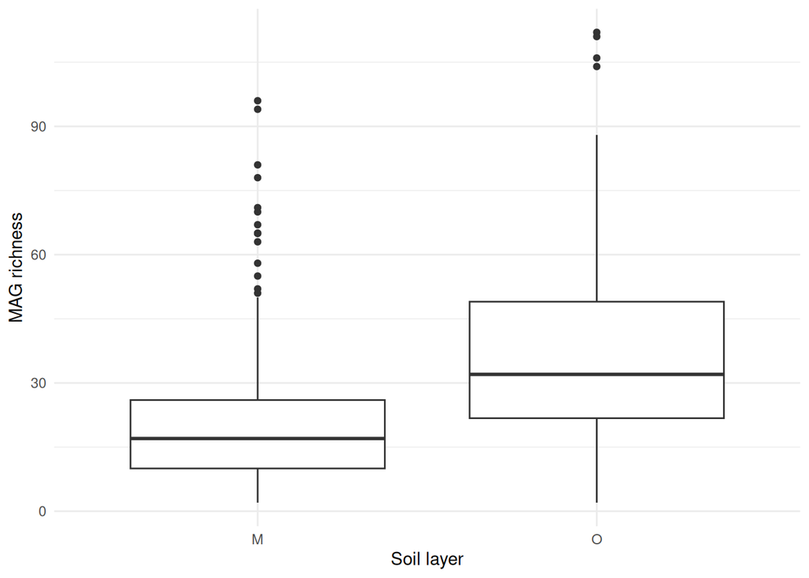

```r
ggplot(alpha_df, aes(x = layer, y = richness)) +
  geom_boxplot() +
  labs(x = "Soil layer", y = "MAG richness") +
  theme_minimal()
```

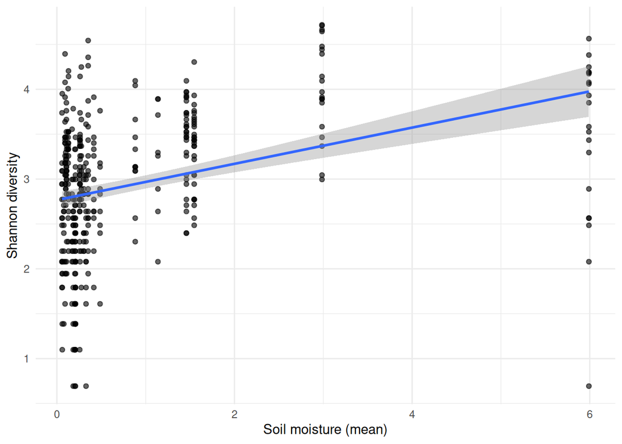

```r
ggplot(alpha_df, aes(x = soilMoisture_mean, y = shannon)) +
  geom_point(alpha = 0.6) +
  geom_smooth(method = "lm", se = TRUE) +
  labs(x = "Soil moisture (mean)", y = "Shannon diversity") +
  theme_minimal()
```

### Beta Diversity (Between-Sample Differences)

What is beta diversity?

Beta diversity measures how different communities are from one another. Instead of focusing on a single sample, it compares pairs of samples.

We use distance (dissimilarity) metrics such as:

- Bray–Curtis distance: considers shared and unique taxa and their relative abundances. Can be used with presence/absence or abundance data.
- Jaccard distance: based only on presence/absence (whether taxa are shared, regardless of abundance).

These distances can be used to:

- Visualize patterns in ordination plots.
- Test for differences among groups using PERMANOVA.

Ordination (NMDS)

Non-metric Multidimensional Scaling (NMDS) is used to visualize complex community differences in 2 or 3 dimensions:

- Calculate a distance matrix between all pairs of samples (e.g., Bray–Curtis).
- NMDS places samples as points in a low-dimensional space so that distances between points reflect community dissimilarities as closely as possible.
- Samples that are close together in the plot have similar communities; samples that are far apart have different communities.

We can then plot the NMDS and color points by site, layer, or other metadata to see how these factors structure community composition.

PERMANOVA

PERMANOVA (Permutational Multivariate Analysis of Variance) tests whether the centroids of community composition differ between groups (e.g., between sites or layers). It uses the distance matrix and metadata.

This tells us whether differences among sites and between layers are statistically significant.

### Community Composition (Taxonomic Summaries)

What is community composition?

Community composition focuses on which taxa are present and their relative contributions to the community. Instead of looking at each MAG individually, we often aggregate MAGs to higher taxonomic levels, such as phylum or class, to see broader patterns.

Questions we can answer:

- Which phyla dominate across all sites?
- Does the relative abundance of major phyla change between soil layers?
- Are some phyla associated with particular environmental conditions?

Aggregating to phylum level

Conceptually, to summarize at the phylum level:

- For each sample, group all MAGs by their phylum (from the taxonomic columns in the dataset).
- Count how many MAGs belong to each phylum in each sample.
- Convert counts to relative abundance (percentage of MAGs in each phylum per sample).
- Create stacked bar plots showing the relative contribution of each phylum across samples, grouped by site or layer.

(In R, this can be done with dplyr::count() and ggplot2::geom_bar().)

Composition results & interpretation

When we look at phylum-level composition across NEON soil samples, common patterns include:

- A small number of phyla dominate most samples, such as Proteobacteria, Acidobacteriota, and Actinobacteriota (exact names depend on the taxonomic annotation used).
- The relative contributions of these phyla vary between:
  - Sites: some sites are enriched in certain phyla, reflecting local climate, vegetation, or soil type.
  - Soil layers: organic horizons often show different phylum profiles compared to mineral horizons, consistent with differences in resource availability and environmental conditions.

These taxonomic patterns complement the diversity and ordination analyses by giving a more biological interpretation of which lineages drive differences between sites and layers.

```r
# Aggregate presence/absence to phylum level
phylum_counts <- dat %>%
  filter(!is.na(phylum)) %>%
  distinct(sample_name, bin_id, phylum) %>%
  count(sample_name, phylum, name = "n_MAGs")

phylum_rel <- phylum_counts %>%
  group_by(sample_name) %>%
  mutate(rel_abund = n_MAGs / sum(n_MAGs)) %>%
  ungroup() %>%
  left_join(meta, by = "sample_name", relationship = "many-to-many")
```

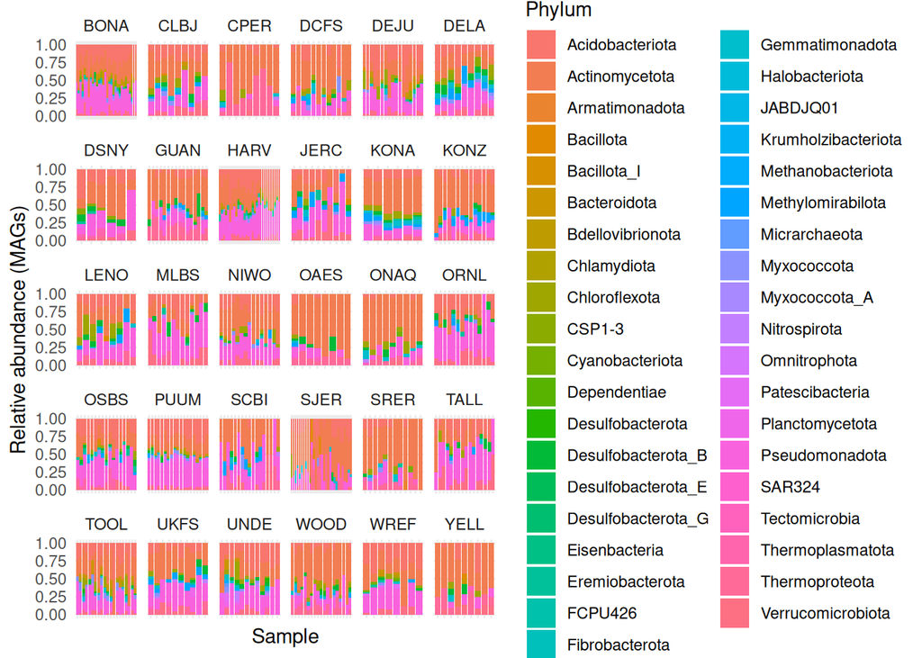

```r
ggplot(phylum_rel, aes(x = sample_name, y = rel_abund, fill = phylum)) +
  geom_bar(stat = "identity") +
  facet_wrap(~ site_ID, scales = "free_x") +
  labs(x = "Sample", y = "Relative abundance (MAGs)", fill = "Phylum") +
  theme_minimal() +
  theme(
    axis.text.x = element_blank(),
    axis.ticks.x = element_blank()
  )
```

### Relationships Between Community Structure and Environment

Linking alpha diversity to environment

By combining diversity indices with environmental variables in the metadata, we can test how environment shapes diversity. For example:

- Linear models (e.g., lm(Shannon ~ moisture + temperature + pH)) allow us to see whether diversity increases or decreases with each variable, while controlling for others.

```r
# Example: Shannon diversity ~ moisture + temperature + pH
alpha_lm <- lm(shannon ~ soilMoisture_mean + soilTemp + soilInWaterpH_mean,
               data = alpha_df)

summary(alpha_lm)
```

```
Call:
lm(formula = shannon ~ soilMoisture_mean + soilTemp + soilInWaterpH_mean,
    data = alpha_df)

Residuals:
    Min      1Q  Median      3Q     Max
-3.2494 -0.4772  0.1160  0.5033  1.8603

Coefficients:
                    Estimate Std. Error t value Pr(>|t|)
(Intercept)         2.953451   0.198681  14.865  < 2e-16 ***
soilMoisture_mean   0.212514   0.032020   6.637 1.06e-10 ***
soilTemp            0.015478   0.006958   2.224  0.02669 *
soilInWaterpH_mean -0.083408   0.030945  -2.695  0.00733 **
---
Signif. codes:  0 '***' 0.001 '**' 0.01 '*' 0.05 '.' 0.1 ' ' 1

Residual standard error: 0.7368 on 396 degrees of freedom
  (25 observations deleted due to missingness)
Multiple R-squared:  0.144, Adjusted R-squared:  0.1376
F-statistic: 22.21 on 3 and 396 DF,  p-value: 2.587e-13
```

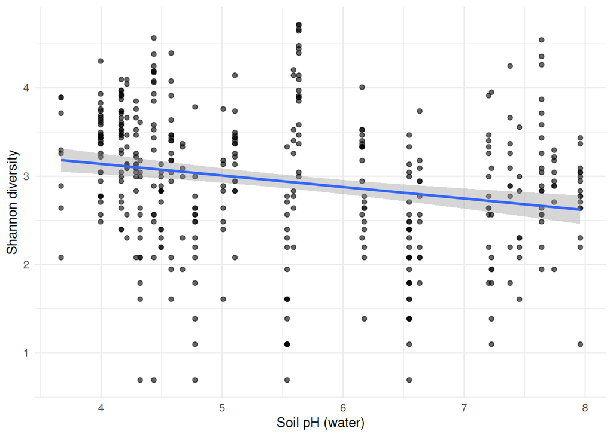

```r
ggplot(alpha_df, aes(x = soilInWaterpH_mean, y = shannon)) +
  geom_point(alpha = 0.6) +
  geom_smooth(method = "lm", se = TRUE) +
  labs(x = "Soil pH (water)", y = "Shannon diversity") +
  theme_minimal()
```

Constrained ordination (db-RDA)

To examine how environment explains differences in composition (beta diversity), we can use distance-based redundancy analysis (db-RDA). Conceptually:

- Start with a Bray–Curtis distance matrix of community composition.
- Use environmental variables (moisture, temperature, pH, etc.) as predictors.
- db-RDA finds axes that represent community variation that can be explained by these predictors.

In R, this is done with capscale() in the vegan package.

```r
# Prepare environmental data aligned with community matrix
env <- meta[rownames(comm_mat),
            c("soilMoisture_mean", "soilTemp",
              "soilInWaterpH_mean", "soilInCaClpH_mean")]

# Standardize environmental variables
env_scaled <- as.data.frame(scale(env))

# db-RDA: community ~ environment
db_rda <- capscale(comm_mat ~ soilMoisture_mean + soilTemp +
                     soilInWaterpH_mean + soilInCaClpH_mean,
                   data = env_scaled,
                   distance = "bray")
```

[output not shown]

```r
anova(db_rda)              # overall significance
```

[output not shown]

```r
anova(db_rda, by = "term") # individual predictors
```

[output not shown]

```r
plot(db_rda, display = c("sites", "bp"))
```

[output not shown]

### Conclusions

Overall, this project illustrates how to:

This workflow is general and can be reused for many other community datasets in R, not only for soil MAGs or NEON data.